# Food at College

```r
# From your file menu (at the top of R-Studio) select:
# "Session -> Set working directory -> To source file location"
# Then play this chunk to get the data into R.
library(mosaic)
library(car)
library(DT)
library(pander)
library(ggplot2)
library(readr)
food <- read_csv("../../Data/food.csv") #food.csv is in the Data folder...
```

## Background

I have always heard that a healthy diet will help you perform better in school so I wanted to compare how much the likelihood of a student eating Fruits or Veggies in any given day affects GPA. The data that I will be using to test this hypothesis comes from a survey of college students. As the current data set doesn’t contain a factor of propensity for veggies or fruits combined, just one or the other, I have decided to create a third factor that is representative of them both. This is done by combining the two 5 level factors into one 25 level factor with a new level for each possible combination.

Below is my attempt to explain the process by which I created the third factor. X axis is propensity to eat fruit and the Y axis is the propensity to each veggies, because I felt a propensity of 2 for veggies and a propensity of 1 for fruit was different than a propensity of 1 for veggies and a propensity of 2 for fruit, I didn’t simply just take the product of x and y but rather a sum of the two levels and let veggies take the larger of the numbers when a tie was present.

[output not shown]

```r
food[68, 2] = "144"
food[4, 2] = "240"

food2 <- food[-c(3,62,105),]
library(tidyr)
food2 <- food2 %>% drop_na(GPA, weight)
#Clean Data, had hanging "lbs", Said "Not sure, guess 240", and "I will not awnser"
```

```r
#Create 3rd Factor of Fruit/Veggie interaction
food2$`Fruit-Veggie` <- case_when(food2$fruit_day == 1 & food2$veggies_day == 1 ~ 1,
                                  food2$fruit_day == 1 & food2$veggies_day == 2 ~ 2,
                                  food2$fruit_day == 1 & food2$veggies_day == 3 ~ 6,
                                  food2$fruit_day == 1 & food2$veggies_day == 4 ~ 10,
                                  food2$fruit_day == 1 & food2$veggies_day == 5 ~ 15,
                                  food2$fruit_day == 2 & food2$veggies_day == 1 ~ 2,
                                  food2$fruit_day == 2 & food2$veggies_day == 2 ~ 5,
                                  food2$fruit_day == 2 & food2$veggies_day == 3 ~ 9,
                                  food2$fruit_day == 2 & food2$veggies_day == 4 ~ 14,
                                  food2$fruit_day == 2 & food2$veggies_day == 5 ~ 19,
                                  food2$fruit_day == 3 & food2$veggies_day == 1 ~ 4,
                                  food2$fruit_day == 3 & food2$veggies_day == 2 ~ 8,
                                  food2$fruit_day == 3 & food2$veggies_day == 3 ~ 13,
                                  food2$fruit_day == 3 & food2$veggies_day == 4 ~ 18,
                                  food2$fruit_day == 3 & food2$veggies_day == 5 ~ 22,
                                  food2$fruit_day == 4 & food2$veggies_day == 1 ~ 7,
                                  food2$fruit_day == 4 & food2$veggies_day == 2 ~ 12,
                                  food2$fruit_day == 4 & food2$veggies_day == 3 ~ 17,
                                  food2$fruit_day == 4 & food2$veggies_day == 4 ~ 21,
                                  food2$fruit_day == 4 & food2$veggies_day == 5 ~ 24,
                                  food2$fruit_day == 5 & food2$veggies_day == 1 ~ 11,
                                  food2$fruit_day == 5 & food2$veggies_day == 2 ~ 16,
                                  food2$fruit_day == 5 & food2$veggies_day == 3 ~ 20,
                                  food2$fruit_day == 5 & food2$veggies_day == 4 ~ 23,
                                  food2$fruit_day == 5 & food2$veggies_day == 5 ~ 25
                                  )
```

```r
#convert factors to numeric
food2$fruit_C <- as.character(food2$fruit_day)
food2$fruit_N <- as.numeric(food2$fruit_C)

food2$veg_C <- as.character(food2$veggies_day)
food2$veg_N <- as.numeric(food2$veg_C)
```

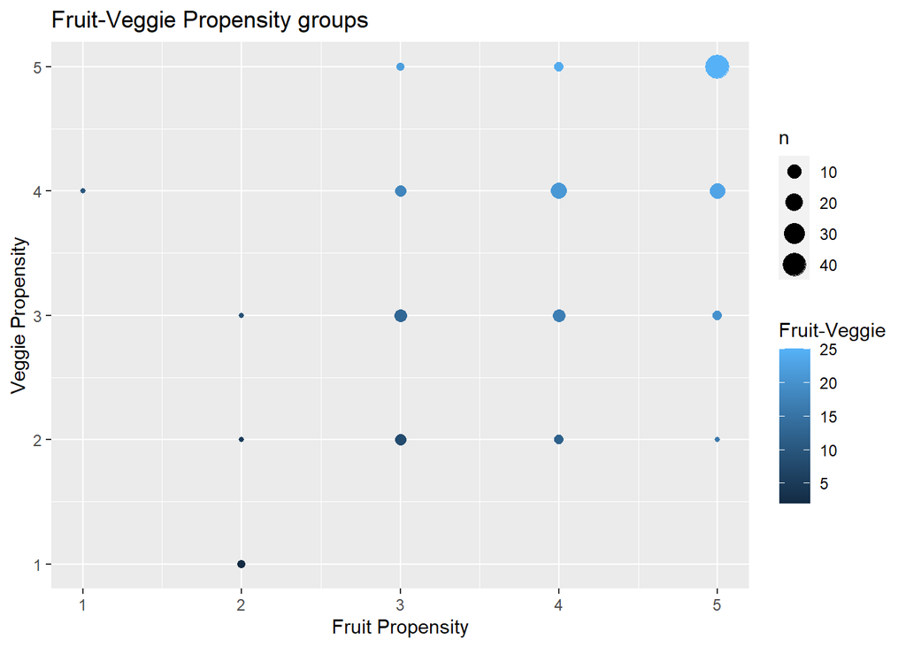

```r
#plot
ggplot(food2, aes( fruit_N , veg_N))+
  geom_count(aes(color=`Fruit-Veggie`))+
  labs(title="Fruit-Veggie Propensity groups", x="Fruit Propensity", y="Veggie Propensity", legend = "Count")
```

## Hypothesis

As stated before I will be looking to see if any of the groups differs from the others in respect to GPA distribution based on Propensity to eat Fruits-Veggies during a given day.
$$H_0: \text{ All samples (Propensity Groups) represent a sample of data taken from the same population (GPA's). }$$

$$H_a: \text{ At least one distribution is stochastically different than the others. }$$
A significance level of 0.05 will be used.

In other words, I am testing to see if any one of the propensity groups has a GPA that is in general different from the others.

## Analysis

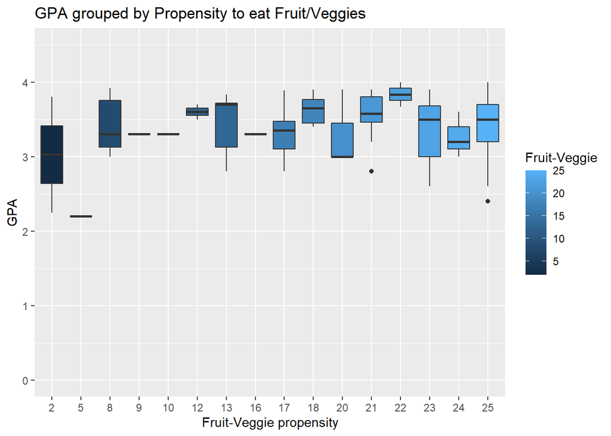

```r
ggplot(food2, aes(x=reorder(as.character(`Fruit-Veggie`), `Fruit-Veggie`), y=as.numeric(GPA), fill=`Fruit-Veggie`))+
   geom_boxplot()+
  labs(title="GPA grouped by Propensity to eat Fruit/Veggies", x="Fruit-Veggie propensity", y="GPA")+
  coord_cartesian(ylim = c(0, 4.5))
```

#### GPA Table

##### Data aggregated as no significant variation is present.

```r
 favstats(food2$GPA)[-9] %>%
    pander(caption = "GPA")
```

GPA

| min | Q1 | median | Q3 | max | mean | sd | n |
| --- | --- | --- | --- | --- | --- | --- | --- |
| 2.2 | 3.2 | 3.5 | 3.7 | 4 | 3.426 | 0.3893 | 118 |

## K-Test

Here are the results of our Kruskal-Wallis test:

```r
kruskal.test(GPA ~ `Fruit-Veggie`, data = food2) %>%
pander()
```

Kruskal-Wallis rank sum test: `GPA` by `Fruit-Veggie`

| Test statistic | df | P value |
| --- | --- | --- |
| 12.96 | 15 | 0.6058 |

## Conclusion

As shown we can see with a P-Value of 0.606 it is highly unlikely that any significant relationship with GPA and propensity to consume fruits or veggies exists, we fail to reject the null. As far as what the relationship for what students ACTUALLY eat we do not know, but at least for what students say they are likely to eat during a given day there does not appear to be any effect on average GPA.